# Day 1:はじめてのオープンデータ処理（１）

# 環境構築

まずは演習環境を整えます．

ここでは二つの拡張パッケージ「RCurl」「ggplot2」をインストールします．

RCurl（ https://cran.r-project.org/web/packages/RCurl/index.html ） は R に HTTP クライアント機能を追加する拡張パッケージです． R から直接ウェブページと取得する等の操作が可能となります．

ggplot2（ http://ggplot2.org/ ） はグラフ描画機能を強化する拡張パッケージです． カラフルなグラフを比較的容易に描くことができます．

それでは早速インストールしてみましょう．

## RCurlパッケージのインストール

以下のコマンドで拡張パッケージをインストールします．

```
install.packages("RCurl")
```

「install.packages」は拡張パッケージをインストールするための関数です．指定した名前の拡張パッケージをCRANから探し出してインストールします．

「RCurl」パッケージを読み込みます．

```
library(RCurl)
```

拡張パッケージの読み込みはRセッション毎に必要です．

以上で「RCurl」のインストールは完了です．

なお，拡張パッケージのインストールと読み込みを実行するスクリプトは以下のとおりです．

```r
if(!require(RCurl)){　# 拡張パッケージはインストールされているか？
  # 拡張パッケージのインストール
  install.packages("RCurl")
  # 拡張パッケージの読み込み
  library(RCurl)
}
```

## ggplot2パッケージのインストール

以下のコマンドで拡張パッケージをインストールします．

```
install.packages("ggplot2")
```

「ggplot2」パッケージを読み込みます．

```
library(ggplot2)
```

以上で「ggplot2」のインストールは完了です．

なお，拡張パッケージのインストールと読み込みを実行するスクリプトは以下のとおりです．

```r
if(!require(ggplot2)){ # 拡張パッケージはインストールされているか？
  # 拡張パッケージのインストール
  install.packages("ggplot2")
  # 拡張パッケージの読み込み
  library(ggplot2)
}
```

# オープンデータの処理

## 使用するデータについて

今回は「HEALTH.DATA.NY.GOV」で公開されている [Baby Names: Beginning 2007](https://health.data.ny.gov/Health/Baby-Names-Beginning-2007/jxy9-yhdk) というデータセットを使います．

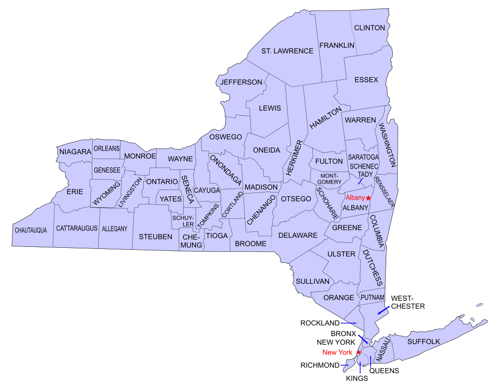

ニューヨーク州の郡，New York Counties by André Koehne and DEIDATVM,https://upload.wikimedia.org/wikipedia/commons/thumb/d/db/New_York_Counties.svg/500px-New_York_Counties.svg.png

HEALTH.DATA.NY.GOV でも加工したり，グラフを描いたりすることができます（最近はこうしたサイトが増えています）．

[figure not shown]

Baby Names: Beginning 2007

## データの読み込み

それでは早速Rにオープンデータを読み込んでみましょう．

URL「 https://health.data.ny.gov/api/views/jxy9-yhdk/rows.csv?accessType=DOWNLOAD 」から直接データを読み込みます．

```
#URLからのデータ読み込み
tmp <- getURL(url="https://health.data.ny.gov/api/views/jxy9-yhdk/rows.csv?accessType=DOWNLOAD",ssl.verifypeer = FALSE)
```

読み込み結果がオブジェクト「tmp」に代入されます．

読み込んだ内容を表示してみましょう．

```
head(tmp)
```

ズラッとデータが表示されます．

### 解説

「getURL」はRCurlパッケージに含まれる関数です．指定したURLからファイルをダウンロードする機能を有します．

オプション「ssl.verifypeer=FALSE」はSSL証明書の検証手順を省略するためのオプションです．

文字コードを指定する場合は「.encoding」オプションを指定します． データ読み込み時に文字化けが発生する場合などに用います．

例えば，ダウンロードするファイルの文字コードが Shift-JIS とわかっている場合は以下のように getURL を呼び出します．

```
# Shift-JIS(CP932)をダウンロードする
tmp<-getURL("http://www.tepco.co.jp/forecast/html/images/juyo-j.csv",.encoding="cp932",.mapUnicode = FALSE)
```

読み込んだ文字コードを別の文字コードに変換する場合は iconv を使います．

```
# Shift-JIS(CP932)からUTF8に変換する．
tmp2<-iconv(tmp,from="cp932",to="utf8")
```

head はデータの先頭を表示する関数です．

```r
head(iris)
```

```
##   Sepal.Length Sepal.Width Petal.Length Petal.Width Species
## 1          5.1         3.5          1.4         0.2  setosa
## 2          4.9         3.0          1.4         0.2  setosa
## 3          4.7         3.2          1.3         0.2  setosa
## 4          4.6         3.1          1.5         0.2  setosa
## 5          5.0         3.6          1.4         0.2  setosa
## 6          5.4         3.9          1.7         0.4  setosa
```

詳しい使い方についてはヘルプ，ウェブリソースを参照してください．

ヘルプは help コマンドで呼び出せます．

```
help(getURL)

または

?getURL
```

## データフレーム形式への変換

データフレーム形式は表形式のデータ構造です．

「習うよりは慣れろ」ということで，先程読み込んだオープンデータを データフレームに変換してみましょう．

```
#Comma Separated Value(CSV) 形式での読み込み
data <- read.csv(text=tmp)
```

### 解説

「read.csv」はデフォルトパッケージに含まれる関数で Comma Separated Value(CSV) ファイルや文字列を データフレームとして読み込む機能を有します．

ちなみにファイルからデータを読み込む場合には以下のように指定します．

```r
#CSVファイルの読み込み
data <- read.csv(file="day01/Baby_Names__Beginning_2007.csv")
```

## データの確認

つぎに データフレーム変換後のデータ内容を確認してみましょう．

まずはデータの先頭行を確認します．

```r
#データの確認（先頭数行のみ）
head(data)
```

```
##   Year First.Name      County Sex Count
## 1 2013      GAVIN ST LAWRENCE   M     9
## 2 2013       LEVI ST LAWRENCE   M     9
## 3 2013      LOGAN    NEW YORK   M    44
## 4 2013     HUDSON    NEW YORK   M    49
## 5 2013    GABRIEL    NEW YORK   M    50
## 6 2013   THEODORE    NEW YORK   M    51
```

データの構造を表示します．

```r
str(data)
```

```
## 'data.frame':    52252 obs. of  5 variables:
##  $ Year      : int  2013 2013 2013 2013 2013 2013 2013 2013 2013 2013 ...
##  $ First.Name: Factor w/ 2120 levels "AADEN","AAHIL",..: 766 1243 1280 869 757 1941 642 1314 2099 517 ...
##  $ County    : Factor w/ 116 levels "Albany","ALBANY",..: 92 92 58 58 58 58 44 44 44 44 ...
##  $ Sex       : Factor w/ 2 levels "F","M": 2 2 2 2 2 2 1 1 1 1 ...
##  $ Count     : int  9 9 44 49 50 51 16 16 16 16 ...
```

データの要約を確認します．

```r
#データの概要
summary(data)
```

```
##       Year         First.Name            County      Sex
##  Min.   :2007   EMMA    :  322   KINGS      : 4957   F:24630
##  1st Qu.:2009   JACOB   :  316   SUFFOLK    : 4005   M:27622
##  Median :2011   LOGAN   :  307   NASSAU     : 3548
##  Mean   :2011   OLIVIA  :  303   QUEENS     : 3376
##  3rd Qu.:2013   ISABELLA:  291   WESTCHESTER: 2941
##  Max.   :2014   SOPHIA  :  283   ERIE       : 2557
##                 (Other) :50430   (Other)    :30868
##      Count
##  Min.   :  5.00
##  1st Qu.:  6.00
##  Median : 11.00
##  Mean   : 18.06
##  3rd Qu.: 19.00
##  Max.   :297.00
##
```

データの行・列サイズを確認します．

```r
#行・列サイズの確認
dim(data)
```

```
## [1] 52252     5
```

列名を確認してみましょう．

```r
#オープンデータの列名確認
colnames(data)
```

```
## [1] "Year"       "First.Name" "County"     "Sex"        "Count"
```

行名を表示する rownames もあります．

データフレームのアクセス手法は色々とあります．

たとえば，添字を使って1行目を取り出すには以下のようにします．

```r
data[1,]
```

```
##   Year First.Name      County Sex Count
## 1 2013      GAVIN ST LAWRENCE   M     9
```

2行目を取り出すには，

```r
data[2,]
```

```
##   Year First.Name      County Sex Count
## 2 2013       LEVI ST LAWRENCE   M     9
```

1〜5行目を取り出すには，

```r
data[1:5,]
```

```
##   Year First.Name      County Sex Count
## 1 2013      GAVIN ST LAWRENCE   M     9
## 2 2013       LEVI ST LAWRENCE   M     9
## 3 2013      LOGAN    NEW YORK   M    44
## 4 2013     HUDSON    NEW YORK   M    49
## 5 2013    GABRIEL    NEW YORK   M    50
```

1,3,5行目を取り出すには，

```r
data[c(1,3,5),]
```

```
##   Year First.Name      County Sex Count
## 1 2013      GAVIN ST LAWRENCE   M     9
## 3 2013      LOGAN    NEW YORK   M    44
## 5 2013    GABRIEL    NEW YORK   M    50
```

とします．

```r
#data.frameの行数を求める
x<-nrow(data)
data[(x-10):x,]
```

```
##       Year First.Name      County Sex Count
## 52242 2014       GAEL Westchester   M     5
## 52243 2014     MATIAS Westchester   M     5
## 52244 2014    JOAQUIN Westchester   M     5
## 52245 2014     NEYMAR Westchester   M     5
## 52246 2014      PEDRO Westchester   M     5
## 52247 2014      DILAN Westchester   M     5
## 52248 2014   EMILIANO Westchester   M     5
## 52249 2014       RAUL Westchester   M     5
## 52250 2014     OLIVIA     Wyoming   F     5
## 52251 2014      LUCAS     Wyoming   M     5
## 52252 2014    JACKSON     Wyoming   M     5
```

列も同じように添字を指定して取り出すことができます．大量のデータが表示されるので head で絞っています．

```r
head(data[,1])
```

```
## [1] 2013 2013 2013 2013 2013 2013
```

ただ，data.frameの場合，列名が付けられていることが殆どであるため， 通常は列名をつかって値を取り出します．

```r
head(data$Year)
```

```
## [1] 2013 2013 2013 2013 2013 2013
```

データフレームの操作方法がなんとなく理解できたでしょうか．

data.frameは頻繁に登場するデータ構造となるので理解を深めておいてください．

## 簡単な集計

データについてはsummary関数である程度把握できたかと思いますが，もう少し細かくデータを見ていきましょう．

データについて性別の内訳を確認してみます．

**※Count列を無視したSex列の集計であることに注意.以降，不正確ですが table による集計を行います．**

```r
table(data$Sex)
```

```
##
##     F     M
## 24630 27622
```

table はデフォルトパッケージに含まれるクロス集計機能を有する関数です．

つぎに調査年毎のデータ数を確認してみます．

```r
table(data$Year)
```

```
##
## 2007 2008 2009 2010 2011 2012 2013 2014
## 6367 6481 6312 6192 6216 6164 6158 8362
```

同じように調査年毎の性別内訳を確認してみます．

```r
#クロス集計(性別・年毎)
table(data$Sex,data$Year)
```

```
##
##     2007 2008 2009 2010 2011 2012 2013 2014
##   F 3002 3039 2917 2925 2918 2872 2836 4121
##   M 3365 3442 3395 3267 3298 3292 3322 4241
```

このように table 関数を用いるとクロス集計を手軽にできます．

```r
#サンプルデータを作る
g<-rep(c("F","M"),100)
t<-rep(c("A","B","O"),100)
r<-rep(c("A","B","C","D","F"),100)
#ランダムに100個のデータを選択して，データフレームを作成する．
d<-data.frame(gender=sample(g,100),type=sample(t,100),rank=sample(r,100))
#頭のデータを確認する
head(d)
```

```
##   gender type rank
## 1      F    O    C
## 2      F    A    F
## 3      F    O    F
## 4      F    A    C
## 5      F    B    B
## 6      F    A    A
```

```r
#クロス集計（gender,rank）
table(d$gender,d$rank)
```

```
##
##      A  B  C  D  F
##   F 10  8 12  6 15
##   M  6  7 16 12  8
```

```r
#クロス集計(gender,type)
table(d$gender,d$type)
```

```
##
##      A  B  O
##   F 16 17 18
##   M 19 13 17
```

## グラフの描画

クロス集計結果をグラフにしてみましょう．ここではグラフの作成に ggplot パッケージを用います．

性別毎の集計結果を棒グラフにします．x軸は性別，y軸は集計結果とします．

```r
table(data$Sex)
```

```
##
##     F     M
## 24630 27622
```

```r
#クロス集計結果をデータフレームに変換
tbl <- data.frame(table(data$Sex))
#確認
tbl
```

```
##   Var1  Freq
## 1    F 24630
## 2    M 27622
```

```r
#列名の設定
names(tbl) <- c("Sex","Total")
#確認
tbl
```

```
##   Sex Total
## 1   F 24630
## 2   M 27622
```

```r
#各列の確認
tbl$Sex
```

```
## [1] F M
## Levels: F M
```

```r
tbl$Total
```

```
## [1] 24630 27622
```

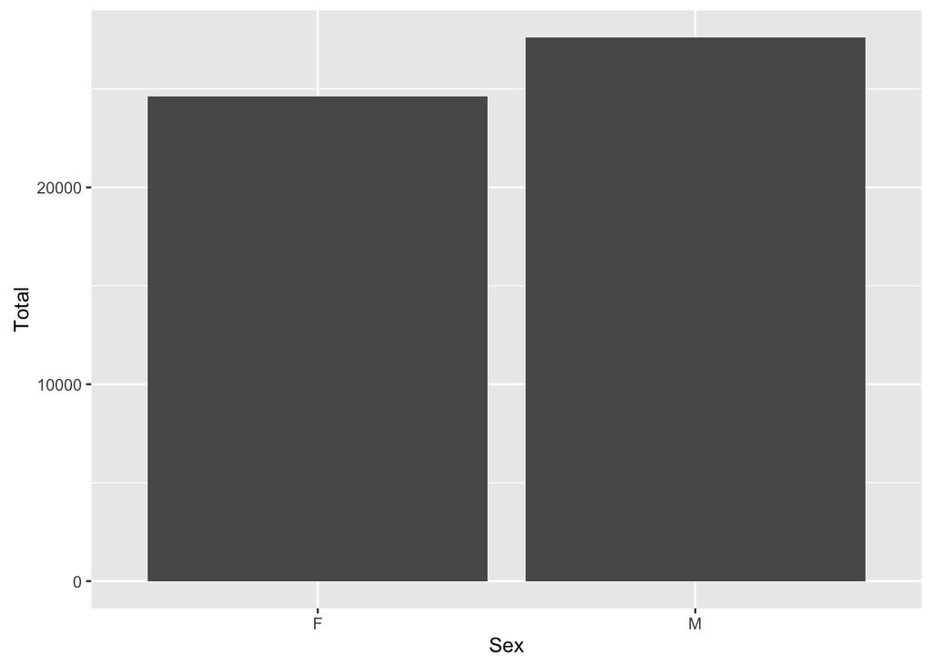

```r
#棒グラフの描画(x軸は性別，y軸は集計結果)
ggplot(data = tbl,mapping = aes(x=Sex,y=Total))+geom_bar(stat="identity")
```

ggplot は data.frameに格納された値を用いてグラフを描画します．

引数「data = tbl」で描画に用いる データフレームを設定しています． 引数「mapping = aes(x=Sex,y=Total)」でX軸，Y軸に用いるdata.frameの列を指定しています． 「+geom_bar(stat=“identity”)」で棒グラフを描画しています．

引数「mapping = aes(x=Sex,y=Total)」に「fill=Sex」を追加すると，性別による塗り分けが可能です．

```
ggplot(data = tbl,mapping = aes(x=Sex,y=Total,fill=Sex))+geom_bar(stat="identity")
```

## 練習問題

グラフを描いてみよう．

### 調査年(Year)毎の集計グラフ

ヒント：調査年毎の集計表はtable(data$Year)で作れます．

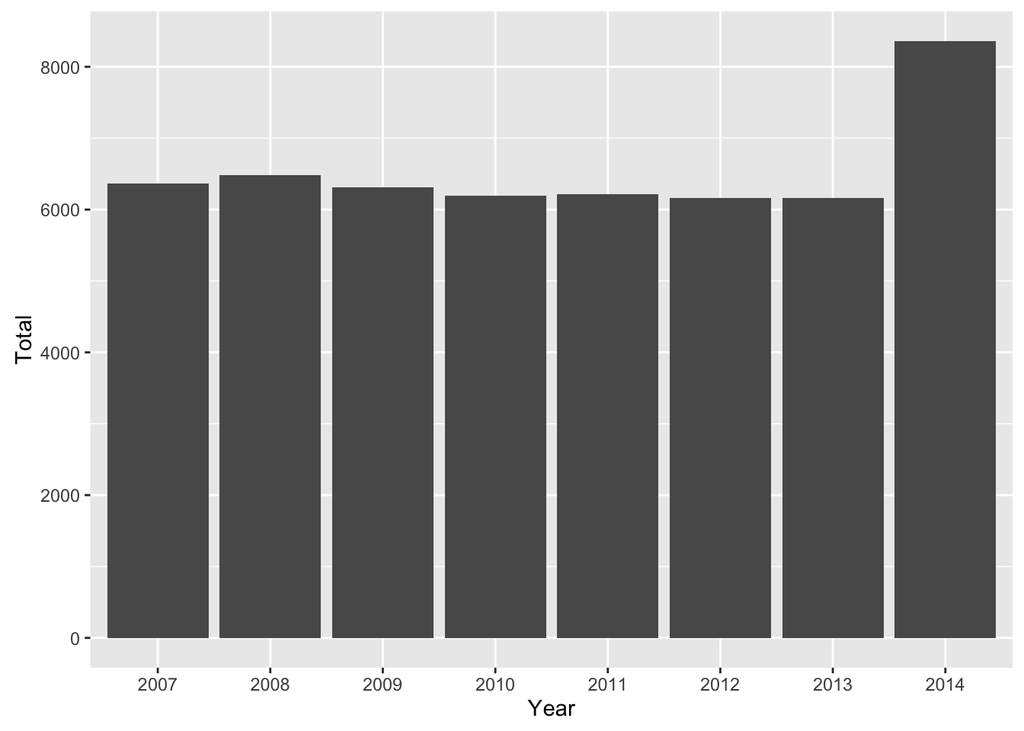

### 郡(County)毎の集計グラフ

ヒント：郡(County)毎の集計表はtable(data$County)で作れます．

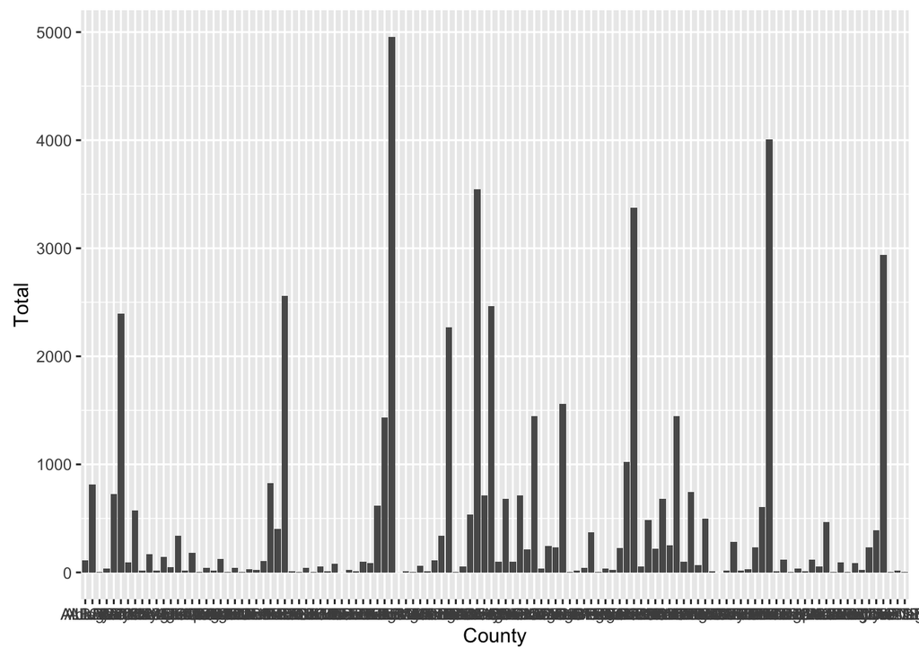

## ステップアップ

### x軸ラベルの回転

theme関数のaxis.text.xオプションを使ってX軸ラベルを回転させることができます．

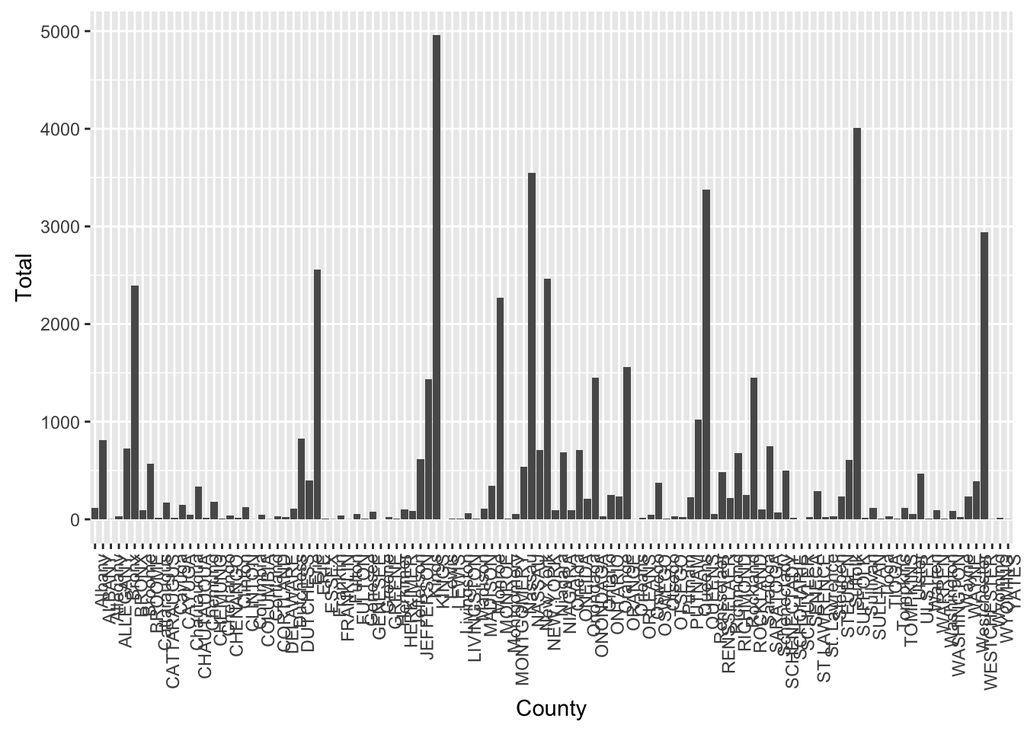

```r
#クロス集計結果をデータフレームに変換
tbl <- data.frame(table(data$County))
#列名の設定
names(tbl) <- c("County","Total")
#グラフの描画
ggplot(tbl,aes(x=County,y=Total))+geom_bar(stat="identity")+theme(axis.text.x = element_text(angle = 90, hjust = 1))
```

### 積み上げ棒グラフの作成

積み上げ棒グラフを作成することもできます．

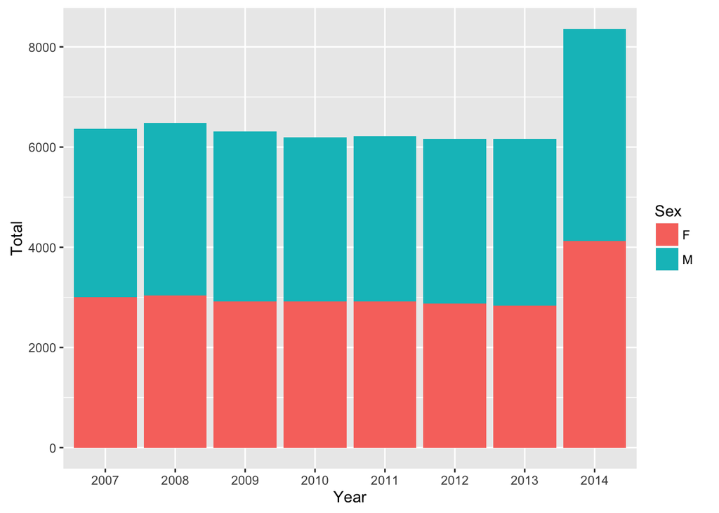

```r
tbl<-data.frame(table(data$Sex,data$Year))
colnames(tbl)<-c("Sex","Year","Total")
ggplot(tbl,aes(x=Year,y=Total,fill=Sex))+geom_bar(stat="identity")
```

### グラフのカスタマイズ

ggplotの結果もオブジェクトに格納することができます．オブジェクトに格納することで，グラフを調整しながら作ることができます．

```r
#クロス集計
table(data$County,data$Sex)
```

```
##
##                   F    M
##   Albany         44   71
##   ALBANY        319  495
##   Allegany        0    3
##   ALLEGANY        9   25
##   Bronx         377  347
##   BRONX        1120 1273
##   Broome         33   57
##   BROOME        201  371
##   Cattaraugus     7   12
##   CATTARAUGUS    52  118
##   Cayuga          4   10
##   CAYUGA         44  101
##   Chautauqua     19   27
##   CHAUTAUQUA    109  228
##   Chemung         6   13
##   CHEMUNG        49  131
##   Chenango        1    3
##   CHENANGO       17   23
##   Clinton         5    9
##   CLINTON        44   78
##   Columbia        1    1
##   COLUMBIA       12   32
##   Cortland        1    2
##   CORTLAND       15   15
##   DELAWARE        5   17
##   Dutchess       46   62
##   DUTCHESS      310  519
##   Erie          196  205
##   ERIE         1278 1279
##   ESSEX           5    4
##   Franklin        1    2
##   FRANKLIN        9   31
##   Fulton          1    1
##   FULTON         19   39
##   Genesee         5    3
##   GENESEE        31   50
##   Greene          0    1
##   GREENE         10   16
```

[output cut: 63 more lines]

```
##   Tompkins        4    6
##   TOMPKINS       36   80
##   Ulster         17   40
##   ULSTER        162  305
##   Warren          2    4
##   WARREN         29   66
##   Washington      1    6
##   WASHINGTON     24   60
##   Wayne           8   15
##   WAYNE          82  152
##   Westchester   189  200
##   WESTCHESTER  1531 1410
##   Wyoming         1    2
##   WYOMING         7   11
##   YATES           0    3
```

```r
#クロス集計結果をデータフレームに変換
tbl <- data.frame(table(data$County,data$Sex))
#列名の設定
names(tbl) <- c("County","Sex","Total")
```

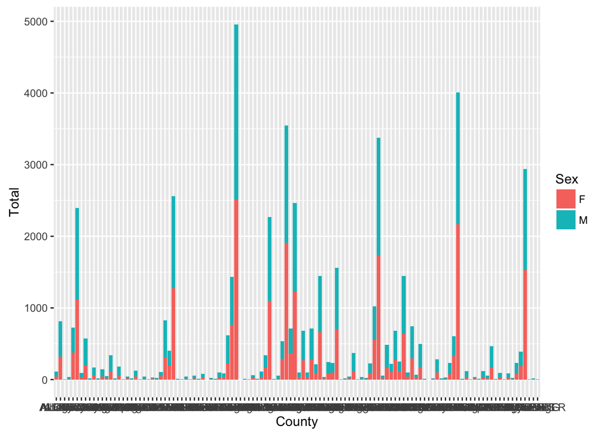

```r
#グラフ作成(x軸は郡，y軸は集計数,塗色は性別毎，ｘ軸ラベルは縦)
g <- ggplot(tbl,aes(x=County,y=Total,fill=Sex))+geom_bar(stat="identity")
#グラフ描画
g
```

X軸ラベルを回転させます．

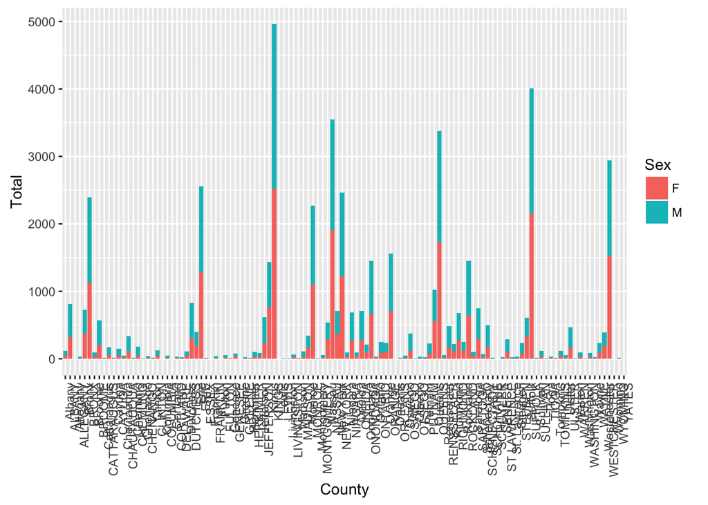

```r
#X軸ラベル回転
g <- g+theme(axis.text.x = element_text(angle = 90, hjust = 1))
#グラフ描画
g
```

グラフタイトルをつけます．

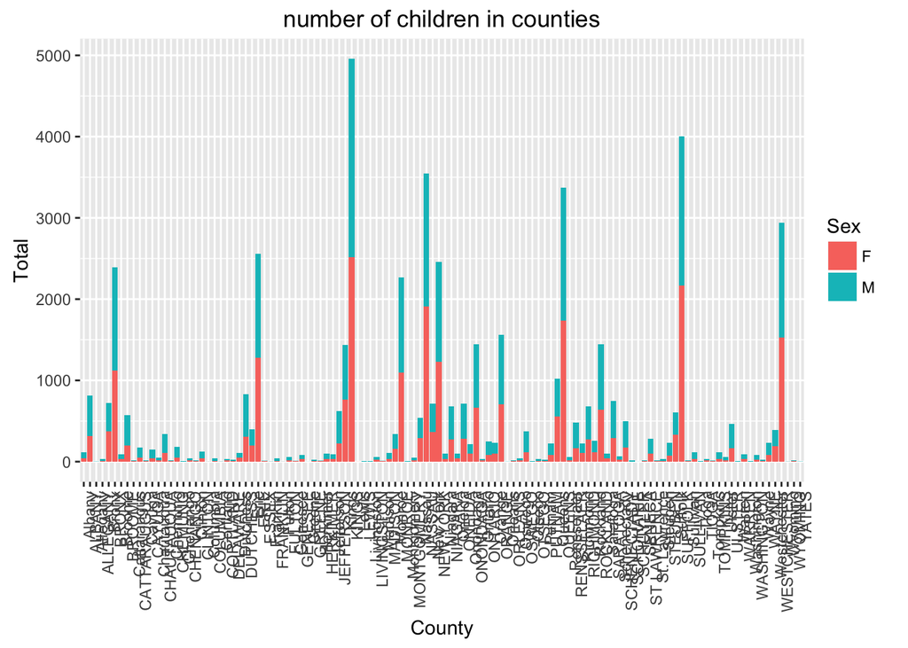

```r
#グラフタイトル
g <- g+ggtitle("number of children in counties")
g
```

オブジェクトに格納したグラフは ggsave 関数で画像ファイルとして保存できます．

```r
ggsave(plot = g,filename = "tmp.png")
```

画像ファイルは，フルパスでない限りワークディレクトリに保存されます．

現在のワークディレクトリは getwd() で取得できます．

```
getwd()
```

ワークディレクトリを設定する場合は setwd(workdir_path) を使います．

```
setwd("c:\tmp")
```

# 課題

グラフタイトル付きの調査年(Year)毎の男女別積み上げ棒グラフを画像ファイルとして提出してください． グラフタイトルの内容は学籍番号と日付としてください．画像ファイル形式はPNG形式（拡張子が.png）とします．

※Count列は無視してください

サンプル：

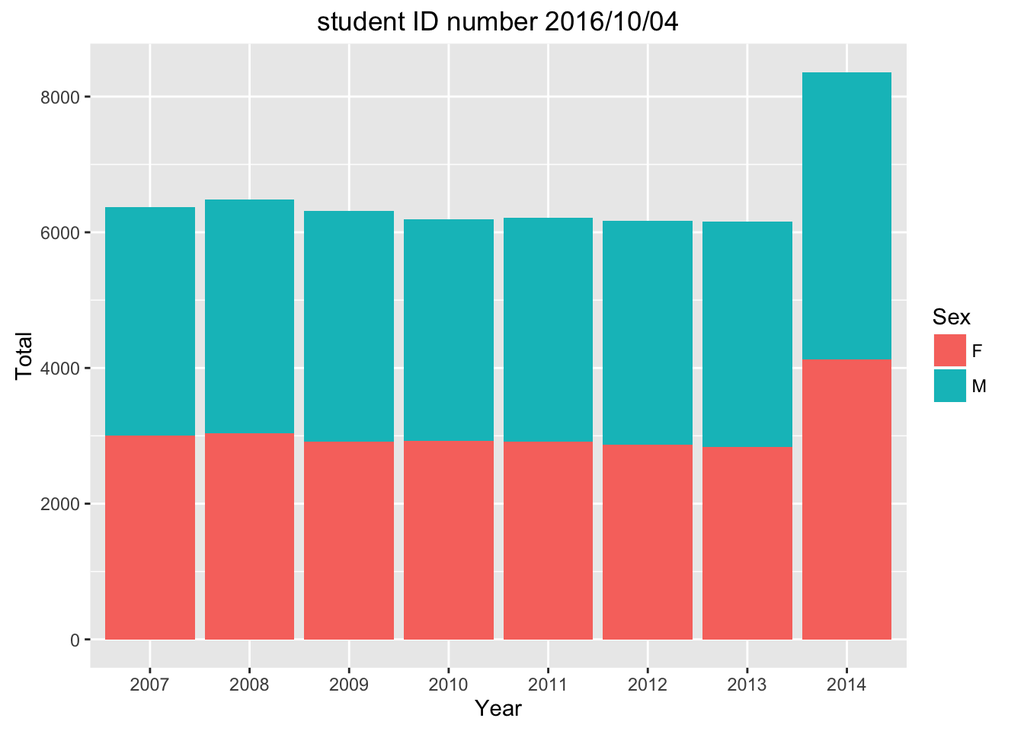

Masaharu Hayashi を著作者とするこの 作品 は [クリエイティブ・コモンズの 表示 4.0 国際 ライセンス](http://creativecommons.org/licenses/by/4.0/)で提供されています。